# Tvyal Newsletter

Aghasi Tavadyan

2023-11-27

Հարգելի գործընկեր,

Հուսով եմ լավ եք: Ներկայացնում եմ անցած շաբաթվա վերլուծությունները և աշխատանքները.

1. Բենզինի գնի թանկացման պատճառները
2. ԶԼՄ հաղորդագրություններ
3. Սպասում եմ ձեզ իմ սթրիմին
4. English summary

## 1. Բենզինի գնy իջնելու է մինչև 400

Սա նախորդ վերլուծության շարունակություննը` [բենզինի գնի վերլուծությունը](https://www.tvyal.com/newsletter/2023_11_20)

Տվյալների բազաները բենզինի գնի, համաշխարհային նավթի և բանզինի գնարի, փոխարժեքի, բենզինի ներմուծման գնի վերաբերյալ կարող եք գտնել ստորև․

- [Petrol Price, Github](https://github.com/tavad/tvyal_newsletter/tree/main/2023_11_20_petrol_price)
- [Petrol Price Forecast, Github](https://github.com/tavad/tvyal_newsletter/tree/main/2023_11_20_petrol_price_forecast)

➡️Բենզինի գինը մոտակա 2 ամիսը կարող է իջնել՝ 400 դրամ

Հայաստանի ու ԱՄՆ բենզինի գնի համեմատությունը։ (Տես գծապատկերը)

Նշեմ որ ճիշտ չէ ուղիղ համեմատել բենզինի գինը Հայաստանում և ԱՄՆ-ում, քանի որ ԱՄՆ-ն նավթ արտադրող և սպառող ամենախոշոր պետությունն է, որը OPEC+ երկրներից արդեն գրեթե նավթ չի ներմուծում։ Հայաստանը նավթի պաշարներ չունի և բենզինի ներմուծում է Ռուսաստանից։ Սակայն համաշխարհային նավթի գները ազդում են բենզինի գնի վրա և՛ ԱՄՆ-ում և՛ Հայաստանի շուկայում, որը երևում է գծապատկերից։ Բենզինի գինը նույն աճի ու նվազման տենդենցները ունի գրեթե բոլոր պետություններում։

Այս պահին բենզինի գինը Հայաստանում ռեկորդային բարձր է։ Ուշադրություն դարձրեք, որ սեպտեմբերի 8-ից բենզինի գինը Հայաստանում գրեթե չի փոխվել է՝ 1.32 դոլար և հոկտեմբերի 4-ին գրանցված ռեգուլյար բենզինի գնի բարձրացումը 540-ից 570 դրամ հիմնականում պայմանավորված էր դրամի արժեզրկումից՝ 380-ից 402 դրամ։ Դոլարով ներմուծման գինը չի փոխվել։

➡️Իջնելո՞ւ է արդյոք բենզինի գինը։

Քննարկենք այն հնարավոր նախապայմանները որոնք կարող են իջեցնել բենզինի գինը։

➡️Ինչքանո՞վ կարող է նվազել բենզինի գինը մեր շուկայում։

Նավթի գնի իջացումը բենզինի գինը կարող է իջեցնել 20 տոկոսով, իսկ դրամի արժևորումը 402-ից 380՝ 5 տոկոսով։ Այդ դեպքում գումարային մոտ 25 տոկոսով կարող է բենզինի գինը իջնել մոտակա 2 ամսում։

Դառնալով՝ Ռեգուլյարը 400 դրամ Պրեմիումը 430 դրամ

- Նշումներ՝ ՀՀ շուկայական գինը փոխանակվել է դոլարի օրվա միջազգային փոխարժեքով։

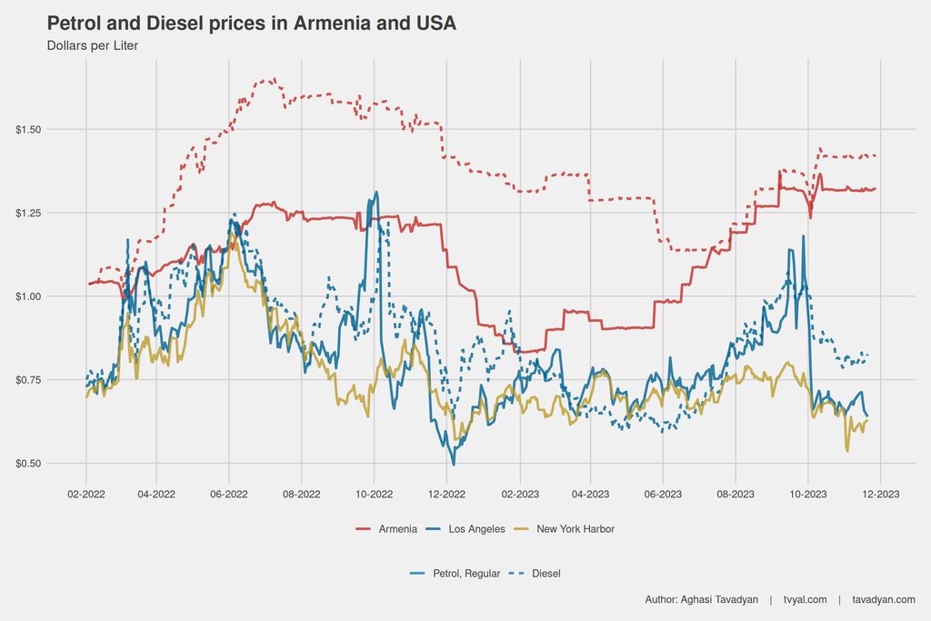

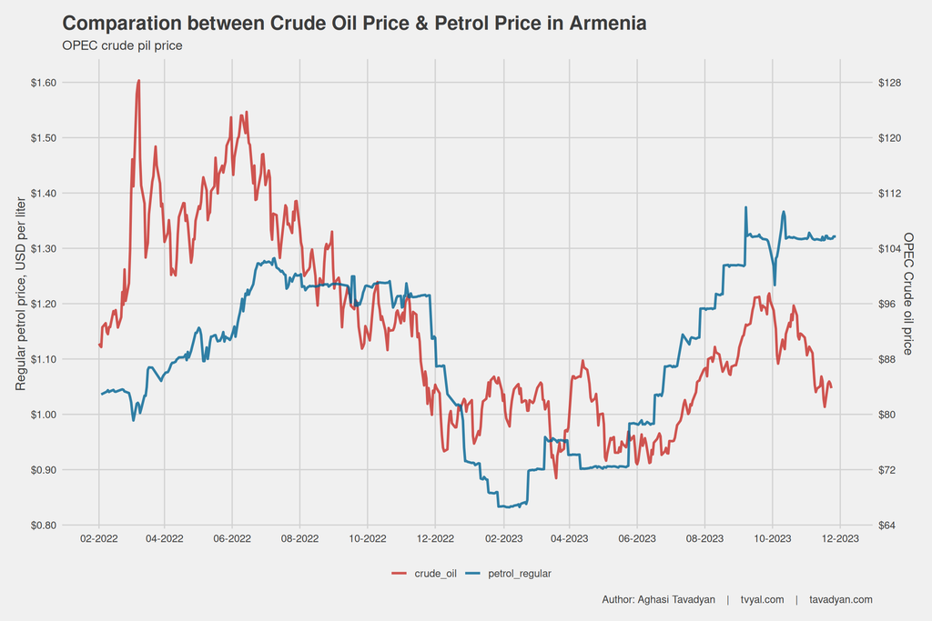

Դոլարը արժեզրկվում է։ Սա որոշակի ճնշում է նաև գործադրում Հայաստանի շուկայի վրա։ Մեծ է հավանականությունը որ դոլարը դառնա 380։ Կարծում եմ արտարժույթ պահելը նպատակահարմար չէ։

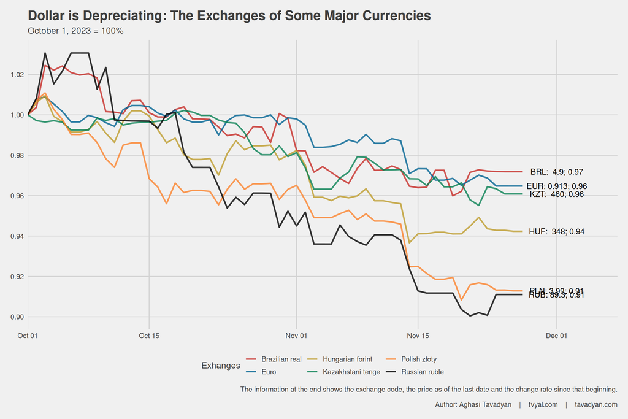

**Հավելյալ տեղեկատվություն.**

## 2. ԶԼՄ հաղորդագրություններ բենզինի գնի մասին

Դիտեք իմ հարցազրույցը տված [1in.am](https://youtu.be/TVdZ1qmq4uI?t=10) լրատվամիջոցոին, թե ինչու բենզինի գինը կարող է դառնալ 400 դրամ:

[figure not shown]

## 3. Սպասում եմ ձեզ իմ սթրիմին

Եթե ձեզ հետաքրքիր է լսել իմ մեկնաբանությունները և տեսնել թե ոնց եմ ես կատարում իմ հետազոտությունները, կարող եք մասնակցել իմ սթրիմին։

Ես նպաստակադրված եմ այն ամենը ինչ անում եմ ներկայացնել և բացատրել սթրիմի կամ վլոգի ձևաչափով: Սա նախնական և փորձնական է լինելու, որը հոսով եմ շարունակական կլինի։

Այս վերլուծությունը առկա է նաև [մեր կայքէջում](https://www.tvyal.com/newsletter/2023_11_27), այս վերլուծության կոդը և տվյալները դրված են նաև [Github-ում](https://github.com/tavad/tvyal_newsletter)։

Եթե հնարավոր է, խնդրում եմ այս նյութը ուղարկել նաև այն մարդկանց, ում այն կարծում եք կարող է հետաքրքրել:

Սպասեք հաջորդ հաղորդագրությանը մի շաբաթվա ընթացքում:

Հարգանքներով,  
Աղասի Թավադյան  
27.11.2023  
[tvyal.com](https://www.tvyal.com/)  
[tavadyan.com](https://www.tavadyan.com/)

**Ուշադրություն. Ձեր էլ.փոստը մեյլիսթի մեջ է, որի միջոցով ես կիսվում եմ շաբաթական նյութեր, որոնք հիմնականում ներկայացնում են Հայաստանի տնտեսությանը: Նյութերը ներառում են գծապատկերներ, [տվյալների բազաներ](https://github.com/tavad/tvyal_newsletter), տեսանյութեր, հոդվածներ, [առցանց վահանակներ](https://www.tvyal.com/projects), տնտեսական գործիքներ, կանխատեսումներ և հաշվետվություններ: Եթե ցանկանում եք չեղարկել բաժանորդագրությունը, խնդրում եմ տեղեկացրեք ինձ, և ես կհեռացնեմ ձեր էլ. փոստը ցուցակից: Գրեք նաև եթե ունեք մենկնաբանություններ:**

**Important! Your email is part of the mailing list where I share weekly materials primarily focused on the Armenian economy. These materials encompass charts, [databases](https://github.com/tavad/tvyal_newsletter), videos, articles, [online dashboards](https://www.tvyal.com/projects), economic tools, forecasts, and reports. If you wish to unsubscribe, please let me know, and I will remove your email from the list. Please share your comments as well․**